# Introduction to the CLIC Package

## Overview

The **CLIC** package provides the tool for feature selection in the context of integrating unpaired scRNA-seq and scATAC-seq data. Unlike traditional feature selection methods that measure solely the gene’s expression variability, CLIC prioritizes genes that show high empirical correlation between expression and nearby accessibility as “high confidence links”.

**CLIC scores**, used as a feature’s confidence score is computed using diverse single-cell multiome data from ENCODE. The script used for computing CLIC scores is available [here](https://github.com/oldvalley49/CLIC_compute)

## Installation

To install the most up-to-date version of CLIC, please install the software via GitHub repo:

```r
devtools::install_github("oldvalley49/CLIC")
```

## Usage

The main function, `FindCLICFeatures()` accepts scRNA-seq data in either:

- A **Seurat object** (recommended)
- A gene expression matrix (raw counts data)

## Example: Human BMMC Data

For convenience, the processed data for [human BMMC](https://datasets-benchmarks-proceedings.neurips.cc/paper/2021/file/158f3069a435b314a80bdcb024f8e422-Paper-round2.pdf) is available for download [here](https://www.dropbox.com/scl/fi/kf6jpe6wpa4zm7eethbjc/BMMC-s4d8.Rdata?rlkey=vctrspsnerfeliatsu40w4rh7&st=e2ad0lty&dl=0) in .Rdata format.

It is worth noting that this data is originally a **multiome** data, meaning both modalities were simultaneously sampled. This is **not** the setting in which CLIC would be used in a realistic scenario. Users should apply CLIC to integrate separately sampled scRNA-seq and scATAC-seq data.

Here, we treat the two modalities as originating from different experiments for demonstration and evaluation purposes only. We load the RNA and ATAC data separately, pretending that we don’t know their ground-truth pairing information.

We demonstrate how CLIC can be integrated into the Seurat workflow. However, CLIC is effective for any integration framework that aligns gene and scATAC-seq peaks via the proximity assumption.

First, load the scRNA-seq data and scATAC-seq data. Gene activity scores are pre-computed by summing the number of fragments overlapping the gene and its promoter region.

We can follow the [standard Seurat preprocessing pipeline](https://satijalab.org/seurat/articles/seurat5_atacseq_integration_vignette) and in the process, find the CLIC features to use for integration.

```r
library(CLIC)
library(Seurat)
library(Signac)
library(ggplot2)
# replace with local path to data
load("data/BMMC-s4d8.Rdata")

# RNA preprocessing
rna <- NormalizeData(rna)
out <- FindCLICFeatures(rna, score_name='human-signac-pearson')
use_features <- out$use_features
head(use_features)
rna <- ScaleData(rna, features=use_features)
# ATAC preprocessing
atac <- RunTFIDF(atac)
atac <- FindTopFeatures(atac, min.cutoff = "q0")
atac <- RunSVD(atac)

DefaultAssay(atac) <- "ACTIVITY"
atac <- NormalizeData(atac)
atac <- ScaleData(atac, features = use_features)
```

Using the features found above, we run standard Seurat workflow for integrating scRNA-seq and scATAC-seq data.

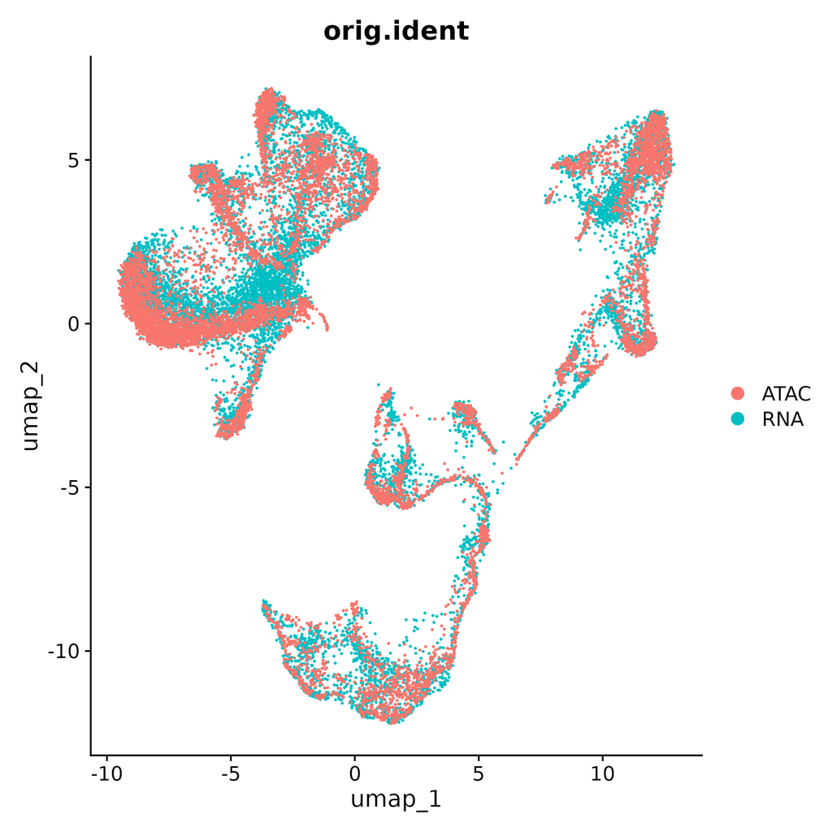

```r
# identify anchors for cca
transfer.anchors <- FindTransferAnchors(reference=rna, query=atac,
                                        features=use_features,
                                        reference.assay = "RNA",
                                        query.assay = "ACTIVITY",
                                        reduction = "cca")
# coembed into shared latent space
refdata <- GetAssayData(rna, assay = "RNA", layer = "data")
imputation <- TransferData(anchorset = transfer.anchors, refdata = refdata, weight.reduction = atac[["lsi"]],
                            dims = 2:30)
atac[["RNA"]] <- imputation
coembed <- merge(x = rna, y = atac, add.cell.ids = c("RNA", "ATAC"))
coembed <- ScaleData(coembed, features = use_features, do.scale = FALSE)
coembed <- RunPCA(coembed, features = use_features, verbose = FALSE)
coembed <- RunUMAP(coembed, dims = 1:30)
embedding_filtered <- Embeddings(coembed, reduction = "pca")
p <- DimPlot(coembed, group.by = c("orig.ident"))
```

We see that the scRNA-seq and scATAC-seq cells are properly mixed in the latent space.